# Snack analysis

Park, Pablo Chanwoo

Sept. 26th, 2017

> **Executive summary**

### 과자 데이터 분석을 통해 도출한 insight는 다음과 같습니다.

#### 1. 기성 과자에 대한 반감과, 식습관 변화로 기성 과자의 대체재에 대한 수요가 있음

#### 2. 유아(엄마)를 타겟으로 한 과자 시장 수요도 분명히 존재함

#### 3. 그나마 기성 과자 중에서는 꼬북칩이 선방하고 있음

> **목적 및 분석 절차**

#### **분석 목적**

본 과자 데이터 분석은 다음 목적 하에 진행하였습니다.

1. 유행하는 과자 종류에 대한 분석
2. 소비자들이 선호하는 과자의 특성 분석
3. 기타 데이터 기반 insight 발굴

#### **분석 절차**

1. 트위터 포스팅 분석 (최신 데이터)
- 9/13부터 실시간으로 총 8,211개의 ‘과자’ 관련 포스팅을 추출
- 8,211개의 포스팅 중 중복, 광고, 아이돌 관련 포스팅 제거 후 1,479개의 포스팅으로 빈도 분석 수행
2. 네이버 블로그 분석
- 1,000개의 블로그 검색 결과를 추출하여 insight 발굴
- ‘과자’ 외 검색어를 변형하여 의미 있는 결과 도출 시도
- 연관성 외 최신 자료 기준으로 검색 시도
3. library 사용
- KoNLP, tm, worldcloud, Matrix, rvest, httr, dplyr 등 총 7종의 library 사용

```r
library(KoNLP)
library(tm)
library(wordcloud)
library(Matrix)
library(rvest)
library(httr)
library(dplyr)
```

> **트위터 포스팅 분석**

– 트위터 포스팅은 파이썬으로 크롤링 후 정제하여 사용함

*중복된 리트윗이나 ‘ㅋ’, ‘ㅎ’, ‘ㅠ’ 와 같은 단일 문자 필터링*

```r
twitter_txt = readLines('./twitter_text_modified.txt', encoding = 'UTF-8')
twitter_txt = unique(twitter_txt)
twitter_txt = gsub(pattern = '[ㅋㅎㅠㄱㅜ]*', replace='', twitter_txt)
```

– 텍스트를 단어(명사) 별로 구분하고, 출현 빈도를 산출

```r
cps = Corpus(VectorSource(twitter_txt))
dtm = DocumentTermMatrix(cps, control = list(tokenize = extractNoun, removeNumber = T, removePunctuation = T))
rmat <-spMatrix(dtm$nrow,dtm$ncol, i=dtm$i, j=dtm$j, x=dtm$v)

wcount <- colSums(rmat)
wname <- repair_encoding(dtm$dimnames$Terms)
```

– 출연 빈도가 높은 단어 200개 중에 단어 길이가 1이거나, 크게 의미가 없다고 판단되는 단어는 제외 (총 135개, 8번 이상 노출)

```r
sort.var <- sort(wcount,decreasing = T)[200]
idx <- !( grepl('과자', wname) | (wcount<=sort.var)  |nchar(wname)==1 | grepl('내가', wname) | grepl('먹고', wname) | grepl('너무', wname) )
wname.rel <- wname[idx]
wcount.rel <- wcount[idx]
```

– 워드 클라우드로 단어 빈도 확인

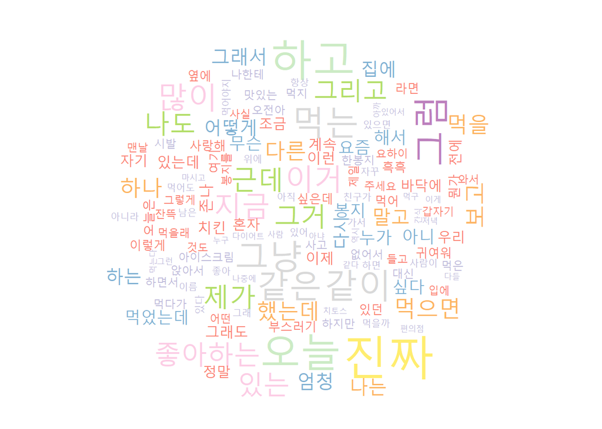

```r
pal <- brewer.pal(12, "Set3")
wordcloud(wname.rel,scale=c(3.9,0.05),freq = wcount.rel, colors = pal)
```

#### **결론**

1. 최근 약 1주간 트위터에 노출 빈도가 높았던 과자 종류는 ‘요하이’(12회)와 ‘치토스’(9회)가 있음
- 실제 데이터를 들여다 본 결과, ’요하이’는 과자 모델인 아이돌 워너원 때문에, ’치토스’는 맥시카나의 치토스치킨 때문에 언급됨
- 각 과자의 인기도를 대변한다고 보기에는 어려우나, 소비자들에게 인지 될 가능성은 있다고 보임
2. ‘아이스크림’ 외 ‘치킨’, ‘라면’, ‘다이어트’ 등도 과자의 대체재가 될 가능성이 높음
- 과자의 대체재는 아이스크림이란 생각이 일반적일 수 있지만, 치킨/라면 등 간단한 식사를 과자의 경쟁상대로 보는 것도 타당한 견해가 될 수 있음
3. 짧은 길이의 포스팅으로 구성되는 트위터인 만큼 단어가 쉬운 경향이 있고, 검색어의 특성을 측정하기에 어려움이 있다고 판단함
- *검색어의 단순성에서 기인한 문제일 가능성도 다분함*

=> Naver 블로그 검색 방식으로 2차 분석 진행

> **Naver 블로그 분석**

– 마찬가지로 ‘과자’ 라는 검색어로 크롤링 진행

```r
client_id = 'pNeL9M2Busi7vWn4XkW6';
client_secret = 'nTY9Mj5v2K';
header = add_headers('X-Naver-Client-Id' = client_id, 'X-Naver-Client-Secret' = client_secret)

query.n = query = '과자'
query = iconv(query, to = 'UTF-8', toRaw = T)
query = paste0('%', paste(unlist(query), collapse = '%'))
query = toupper(query)
```

– 연관성 기준으로 1,000개 데이터 추출 및 데이터 정제

```r
end_num = 1000
display_num = 100
start_point = seq(1, end_num, by = display_num)
i = 1

final_dat = NULL
for(i in 1:length(start_point))
{
  url = paste0('https://openapi.naver.com/v1/search/blog.xml?query=',query,'&display=',display_num,'&start=',start_point[i],'&sort=sim')
  url_body = read_xml(GET(url, header), encoding = "UTF-8")
  title = url_body %>% xml_nodes('item title') %>% xml_text()
  bloggername = url_body %>% xml_nodes('item bloggername') %>% xml_text()
  postdate = url_body %>% xml_nodes('postdate') %>% xml_text()
  link = url_body %>% xml_nodes('item link') %>% xml_text()
  description = url_body %>% xml_nodes('item description') %>% html_text()
  temp_dat = cbind(title, bloggername, postdate, link, description)
  final_dat = rbind(final_dat, temp_dat)
}
```

```r
final_dat = data.frame(final_dat, stringsAsFactors = F)

dat_tmp <- final_dat
for (i in 1:nrow(final_dat))
{
  dat_tmp[i,5]<- gsub('[ㅋㅎㅠㅜ]', '', gsub( "<[/|A-Za-z]*>",  "", gsub("&[a-z]*;",  "", gsub("http[/:a-z.]*",  "", final_dat[i,5]))))
    dat_tmp[i,1]<- gsub('[ㅋㅎㅠㅜ]', '',  gsub( "<[/|A-Za-z]*>",  "", gsub("&[a-z]*;",  "", final_dat[i,1])))
}
```

-– 텍스트를 단어(명사) 별로 구분하고, 출현 빈도를 산출

```r
text = dat_tmp[,5]
cps = Corpus(VectorSource(text))
dtm = DocumentTermMatrix(cps, control = list(tokenize = extractNoun, removeNumber = T, removePunctuation = T))
rmat <-spMatrix(dtm$nrow,dtm$ncol, i=dtm$i, j=dtm$j, x=dtm$v)

wcount <- colSums(rmat)
wname <- repair_encoding(dtm$dimnames$Terms)
```

– 출연 빈도가 높은 단어 200개 중에 단어 길이가 1이거나, 크게 의미가 없다고 판단되는 단어는 제외 (총 136개, 13번 이상 노출)

```r
sort.var <- sort(wcount,decreasing = T)[200]
idx <- !( grepl(query.n, wname) | (wcount<=sort.var)  |nchar(wname)==1 |grepl('있', wname))
wname.rel <- wname[idx]
wcount.rel <- wcount[idx]
```

– 워드 클라우드로 단어 빈도 확인

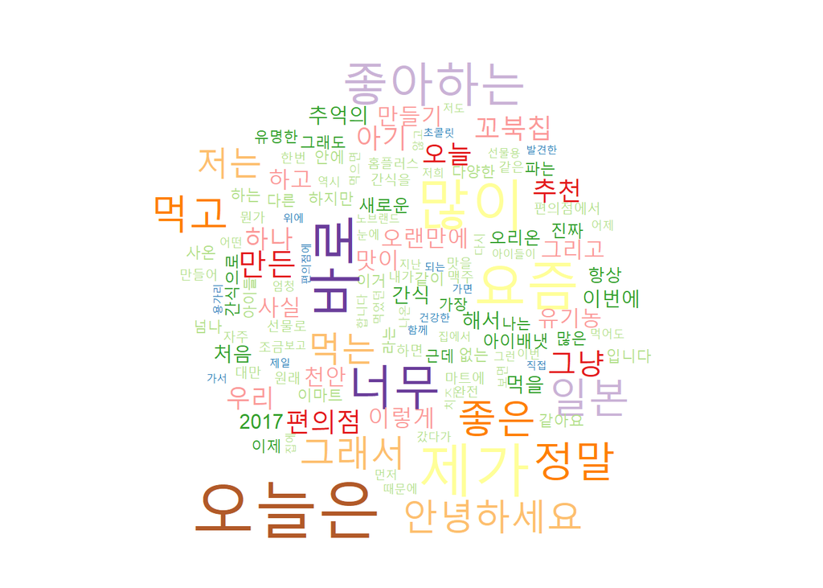

```r
pal <- brewer.pal(12, "Paired")
wordcloud(wname.rel,scale=c(3.8,0.05),freq = wcount.rel, colors = pal)
```

#### **결론**

1. 기성 과자 중에서는 꼬북칩이 우세
- ‘과자’ 검색 연관단어 top 200 중에 유일하게 꼬북칩만 기성 과자 중 이름을 올림
- 한때 SNS 입소문 났던 과자 답게 노출이 많으며, 또 일관되게 긍정적으로 평가 내리고 있음
2. 아기용 과자 (아이배냇, 베베핑거, 유기농 외)
- 기성 과자에 대한 블로그 글보다 유기농 아기용 과자에 대한 블로그 글 수가 더 많아, 이런 관심이 실제로도 상당할 것으로 보임
- 다만, 아기용 과자에 대한 관심이 높은 것은, 소비자의 구매의사결정 과정이 기성 과자보다 아기용 과자를 살때 훨씬 복잡하기 때문일 수 있고 실수요가 기성 과자만큼 높다고 단정짓기는 어려움
- *또한, 블로거 특성 상 2~30대 여성이 주를 이루다 보니 나타나는 현상일 수도 있음*
3. 대체재의 약진 (일본, 대만, 노브랜드, 천안, 편의점)
- 기존 브랜드에 대한 블로그 빈도보다 대체 제품에 대한 블로그 글 빈도가 눈에 띔
- 특히 편의점 PB 제품과 노브랜드에 대한 충성도가 상당한 것으로 보임

> **번외. 기성 과자 중 인기있는 과자 순위는?**